# Supplementary Materials

Understanding online influence using a custom social media platform

# Overview

This document collects the analyses referenced as “Supplementary Materials” in the manuscript. The complete analysis pipeline is split across the numbered Quarto documents at the root of this repository, and full details of every analysis reported in the paper can be reproduced from them:

- **`01_demographics.qmd`** — sample demographics, political identification, and initial beliefs (manuscript Figure 1).
- **`02_engagement.qmd`** — engagement and activity on the platform, including the chi-square tests of engagement composition and polarity (Figure 2).
- **`03_linear-modelling.qmd`** — the Bayesian beta-regression models of condition effects on beliefs, perceptions, trust, and experience (Figures 3–4), and the posts-seen models (Figure 5).
- **`04_supplementary-materials.qmd`** (this document) — the supplementary analyses below.

Shared code is factored into sourceable scripts so that nothing is defined twice: model-fitting and plotting helpers live in `R/helper-functions/lm-functions.R`, the posts-seen grid plotters in `R/visualise/functions/posts-seen-grid-plots.R`, and the posts-seen correlation computation in `R/analyse/posts-seen-correlations-prep.R`. Both this document and `03_linear-modelling.qmd` source those scripts rather than redefining the functions.

The sections below correspond to the four places the manuscript points to the Supplementary Materials.

# Individual trust, affective polarisation, and relative-belief breakdowns

*Referenced on p. 18: “An equivalent plot with the breakdown of each individual trust measure is shown in the Supplementary Materials.”*

The main text reports condition effects on the aggregate trust measure (`TrustOverall`), affective polarisation (`AffPol`), and relative-belief (`RelativePolitics`) measures (Figure 3). Here we break those down into their component sub-measures, using the same model structure (`measure After ~ measure Before + Condition`, Bayesian beta regression) and the same plotting function (`plot_lm_and_bar`) as the main analysis.

## Trust and affective polarisation sub-measures

The trust panel shows that, relative to the `Control`, trust in the `Left` condition decreased for businesses, universities, and the government, and that the increase in trust in other people was credibly smallest in the `Left` condition. Trust in the media was the only sub-measure with no credible difference from `Control`.

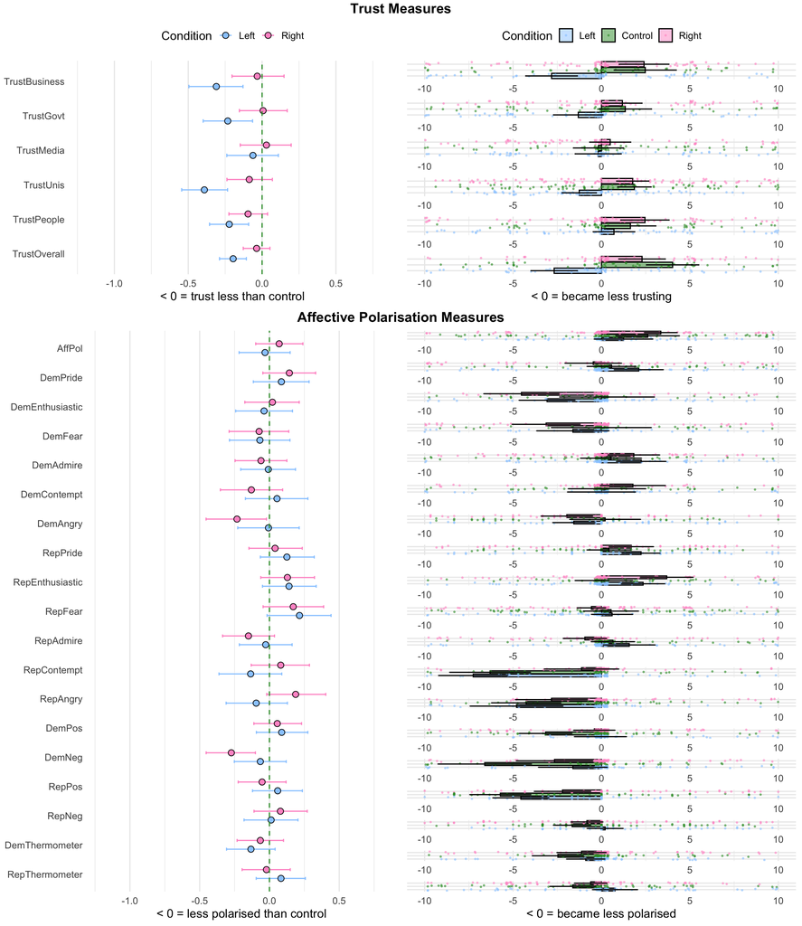

## Relative-belief sub-measures (by topic)

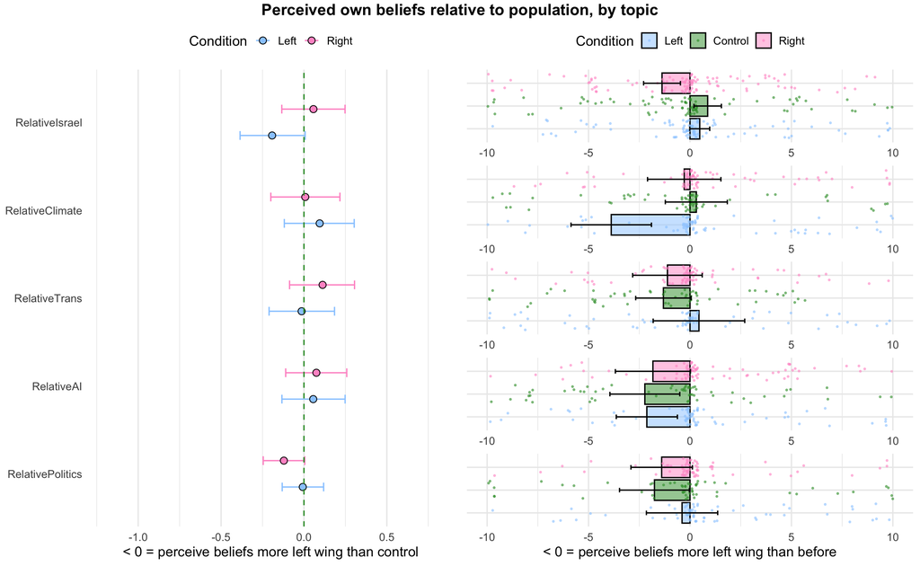

# Comparing the full sample to the posts-seen sub-sample

*Referenced on p. 22 (footnote 4): “The sample with these exclusions did not differ from the full sample in their initial beliefs, political identification, perceptions of consensus, or age … See the Supplemental Materials for more details.”*

```
[1] "Posts seen data is missing for 146 participants total"
```

```
[1] "Breakdown by condition: "
```

```
# A tibble: 3 × 2
  Condition Missing
  <chr>       <int>
1 Control        93
2 Left           21
3 Right          32
```

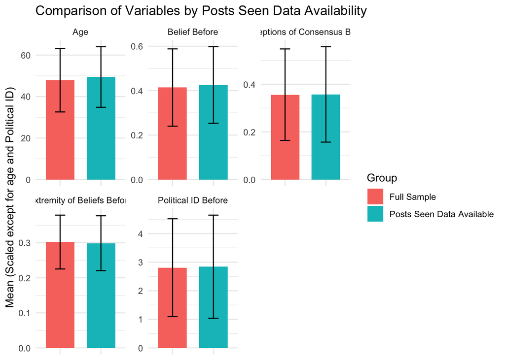

For completeness, the table below reports the mean and variance of the total proportion of political content seen in each condition, for all content, for troll-initiated content, and for non-troll-initiated content.

```
# A tibble: 3 × 7
  Condition var_troll mean_troll var_nontroll mean_nontroll  var_all mean_all
  <chr>         <dbl>      <dbl>        <dbl>         <dbl>    <dbl>    <dbl>
1 Control    NA          NaN          NA            NaN     NA        NaN
2 Left        0.0156       0.474       0.0559         0.907  0.0143     0.540
3 Right       0.00934      0.557       0.0893         0.849  0.00798    0.620
```

# Posts-seen analysis: correlation equivalent of Figure 5

*Referenced on p. 23 (footnote 6): “We also repeated the same analyses as shown in Figure 5 using correlations between the posts participants saw and each variable, which yielded very similar results (see Supplementary Materials).”*

Figure 5 in the main text uses Bayesian beta-regression coefficients to relate the proportion of each post type a participant saw (Right, Left, Friendly) to the change in each outcome measure, comparing all content seen to non-troll-initiated content only. Here we reproduce that comparison using simple correlations rather than the regression models. The correlation objects are computed in `R/analyse/posts-seen-correlations-prep.R` (sourced below) and plotted with the same `plotCorrelationsGrid()` plotting function used for the main figure, so the two figures are directly comparable.

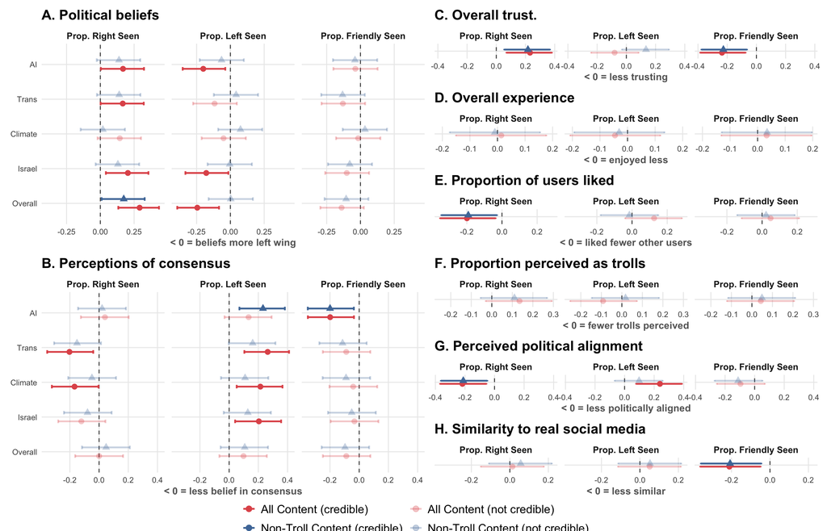

## Trust sub-measures (correlation and coefficient grids)

The same posts-seen comparison broken down by individual trust sub-measure rather than the aggregate trust measure, shown both as correlations and as the Bayesian regression coefficients from Figure 5.

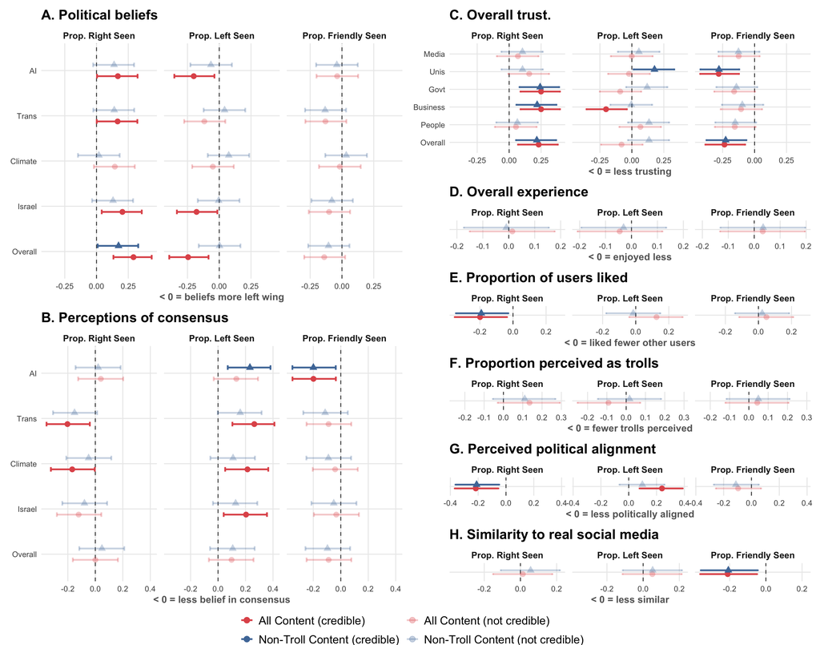

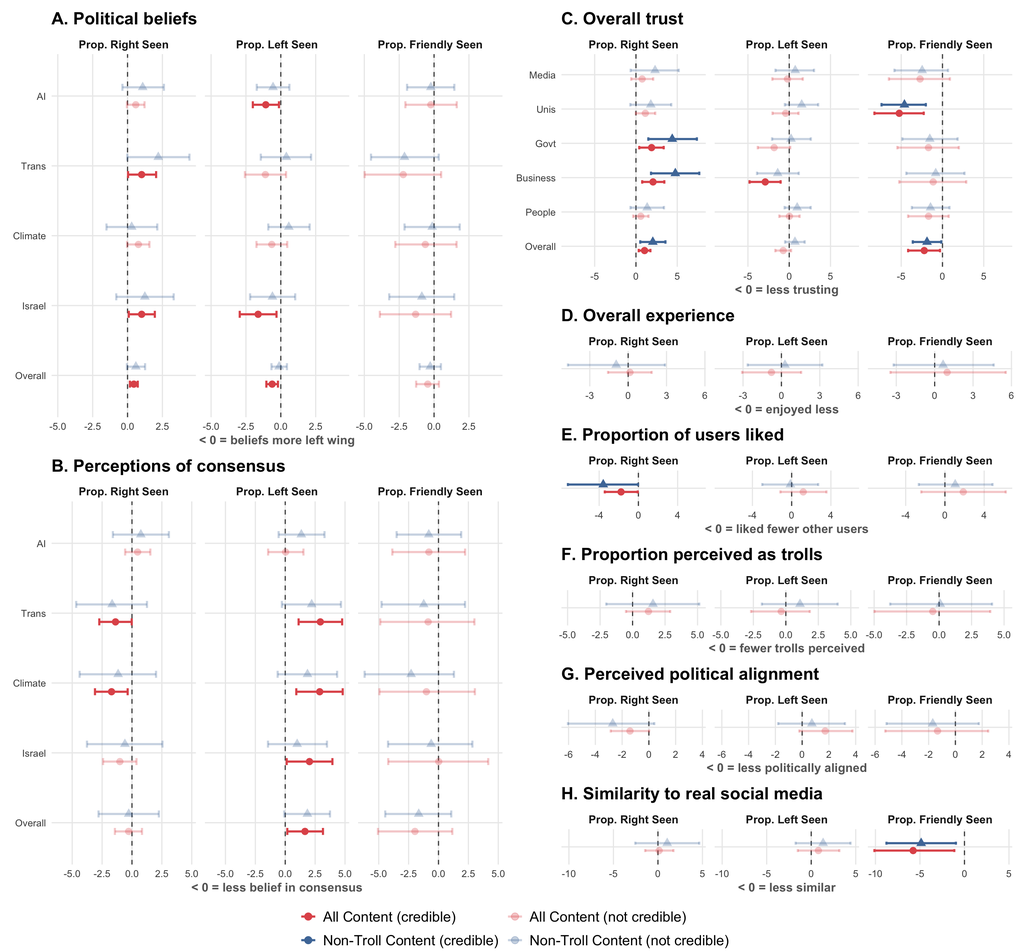